# Titanic - Machine Learning from Disaster: Logistic Regression

Lily Zou

## 1 Summary

The purpose of this project was to investigate which factors impact an individual’s likelihood of surviving the sinking of the Titanic and construct a model to accurately predict a Titanic passenger’s survival outcome. Since the outcome is binary (0: perished, 1: survived) we use logistic regression to construct a model.

The datasets used are available at https://www.kaggle.com/c/titanic/data.

## 2 Data

### 2.1 Read Data

```r
train = read.csv("train.csv", header = T, na.strings = c(""))
test = read.csv("test.csv", header = T, na.strings = c(""))

train$Pclass = factor(train$Pclass)
test$Pclass = factor(test$Pclass)

summary(train)
```

```
##   PassengerId       Survived      Pclass
##  Min.   :  1.0   Min.   :0.0000   1:216
##  1st Qu.:223.5   1st Qu.:0.0000   2:184
##  Median :446.0   Median :0.0000   3:491
##  Mean   :446.0   Mean   :0.3838
##  3rd Qu.:668.5   3rd Qu.:1.0000
##  Max.   :891.0   Max.   :1.0000
##
##                                     Name         Sex           Age
##  Abbing, Mr. Anthony                  :  1   female:314   Min.   : 0.42
##  Abbott, Mr. Rossmore Edward          :  1   male  :577   1st Qu.:20.12
##  Abbott, Mrs. Stanton (Rosa Hunt)     :  1                Median :28.00
##  Abelson, Mr. Samuel                  :  1                Mean   :29.70
##  Abelson, Mrs. Samuel (Hannah Wizosky):  1                3rd Qu.:38.00
##  Adahl, Mr. Mauritz Nils Martin       :  1                Max.   :80.00
##  (Other)                              :885                NA's   :177
##      SibSp           Parch             Ticket         Fare
##  Min.   :0.000   Min.   :0.0000   1601    :  7   Min.   :  0.00
##  1st Qu.:0.000   1st Qu.:0.0000   347082  :  7   1st Qu.:  7.91
##  Median :0.000   Median :0.0000   CA. 2343:  7   Median : 14.45
##  Mean   :0.523   Mean   :0.3816   3101295 :  6   Mean   : 32.20
##  3rd Qu.:1.000   3rd Qu.:0.0000   347088  :  6   3rd Qu.: 31.00
##  Max.   :8.000   Max.   :6.0000   CA 2144 :  6   Max.   :512.33
##                                   (Other) :852
##          Cabin     Embarked
##  B96 B98    :  4   C   :168
##  C23 C25 C27:  4   Q   : 77
##  G6         :  4   S   :644
##  C22 C26    :  3   NA's:  2
##  D          :  3
##  (Other)    :186
##  NA's       :687
```

The train dataset contains the following variables:

- PassengerId: A passenger’s unique ID number
- Survived: A binary variable denoting whether a passenger survived (1) or perrished (0)
- Pclass: Passenger’s class (1st, 2nd, 3rd), listed as a proxy for socio-economic status
- Name: Passenger’s name
- Sex: Passenger’s sex
- Age: Passenger’s age
- SibSp: Number of siblings and/or spouses a passenger had abord the Titanic
- Parch: Number of parents and/or children a passenger aboard the Titanic
- Ticket: Passenger’s ticket number
- Fare: Fare passenger paid for the ticket
- Cabin: Passenger’s cabin number
- Embareked: Where the passenger boarded the ship (C = Cerbourg, Q = Queenstown, S = Southamptom)

### 2.2 Missing Values

Note that there are several variables with missing values:

```r
sapply(train, function(x) sum(is.na(x)))
```

```
## PassengerId    Survived      Pclass        Name         Sex         Age
##           0           0           0           0           0         177
##       SibSp       Parch      Ticket        Fare       Cabin    Embarked
##           0           0           0           0         687           2
```

```r
sapply(test, function(x) sum(is.na(x)))
```

```
## PassengerId      Pclass        Name         Sex         Age       SibSp
##           0           0           0           0          86           0
##       Parch      Ticket        Fare       Cabin    Embarked
##           0           0           1         327           0
```

Just over 77% of the data points for ‘Cabin’ are missing in the train dataset. Therefore we assumed ‘Cabin’ is insignificant to predict survival and exclude this variable from the model.

```r
train = subset(train, select= c(1:10, 12))
test = subset(test, select= c(1:9, 11))
```

Only 2 data points for ‘Embarked’ are missing (0.22% of the total observations) in the train dataset. Therefore we discard these two incomplete observations under the assumption that not much information will be lost.

```r
train = train[!is.na(train$Embarked),]
```

To fill in the missing data points for ‘Age’ we use multiple imputation via sampling with replacement.

```r
set.seed(123)
train$Age = complete(mice(data = subset(train, select = c(2, 6)), m = 1, maxit = 100, method = "sample", print = FALSE), action = 1)$Age

test$Age = complete(mice(data = subset(test, select = c(4,5)), m = 1, maxit = 100, method = "sample", print = FALSE), action = 1)$Age
```

### 2.3 Data Exploration

We remove ‘Name’ and ‘Ticket’ and ‘PassengerId’ from the dataset due to each name, passengerID and ticket number as said variables are unlikely to be related to survival probability.

```r
train = subset(train, select = c(2, 3, 5, 6, 7, 8, 10, 11))
test = subset(test, select = c(1, 2, 4, 5, 6, 7, 9, 10))
```

We begin by exploring the relationship between the remaining variables and survival outcome.

Sex and Survival

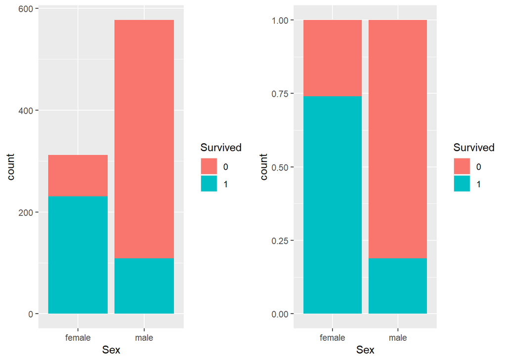

```r
train$Survived = factor(train$Survived)
plot1 = ggplot(train, aes(x=Sex, fill=Survived)) + geom_bar()
plot2 = ggplot(train, aes(x=Sex, fill=Survived)) + geom_bar(position = "fill")
grid.arrange(plot1, plot2, ncol=2)
```

From the figures we can see that overwelmingly, females survive more than males referencing the “Women and children first” principal.

PClass and Survival

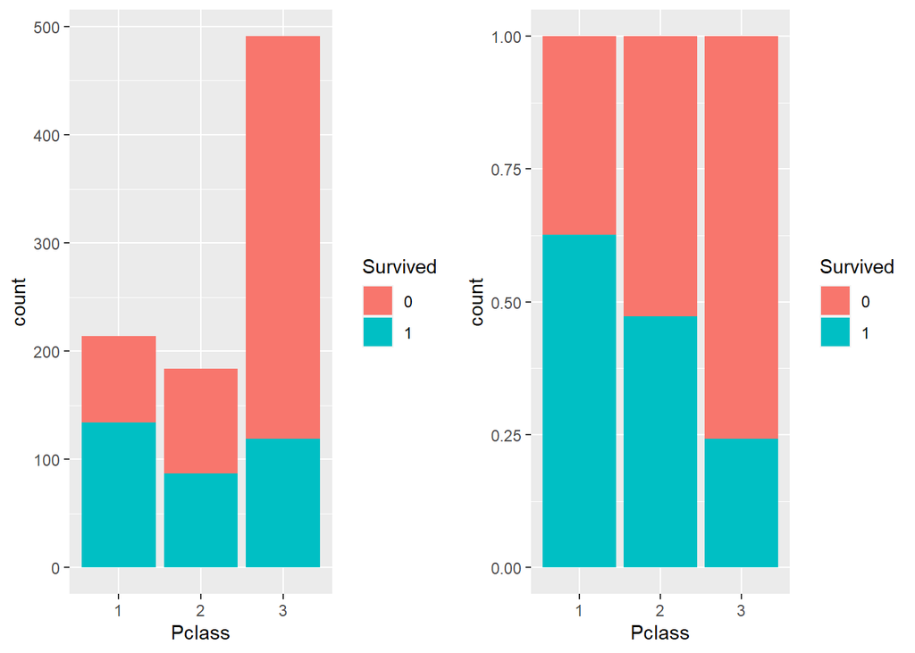

```r
plot1 = ggplot(train, aes(x=Pclass, fill=Survived)) + geom_bar()
plot2 = ggplot(train, aes(x=Pclass, fill=Survived)) + geom_bar(position = "fill")
grid.arrange(plot1, plot2, ncol=2)
```

From the figures we can see that passengers in 3rd class tended to perish much more often than to passengers in 1st and 2nd class.

Age and Survival

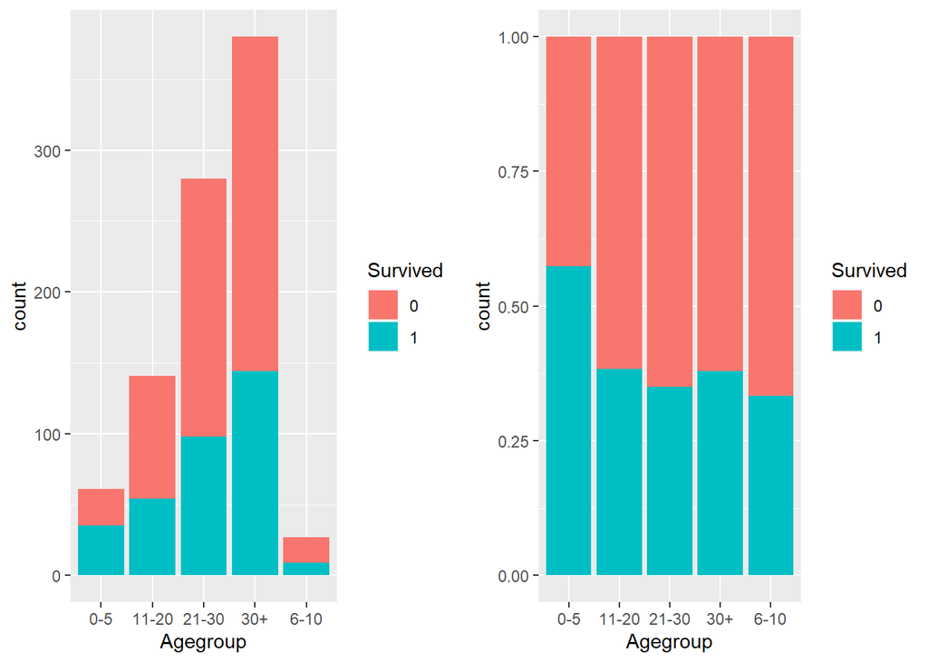

```r
train$Agegroup[train$Age <= 5] <- "0-5"
train$Agegroup[train$Age > 5 & train$Age <= 10] <- "6-10"
train$Agegroup[train$Age > 10 & train$Age <= 20] <- "11-20"
train$Agegroup[train$Age > 20 & train$Age <= 30] <- "21-30"
train$Agegroup[train$Age > 30] <- "30+"
plot1 = ggplot(train, aes(x=Agegroup, fill=Survived)) + geom_bar()
plot2 = ggplot(train, aes(x=Agegroup, fill=Survived)) + geom_bar(position = "fill")
grid.arrange(plot1, plot2, ncol=2)
```

From the figures we can see the proportion of survivors was larger for children under 5, again referencing the “Women and children first” principal.

SibSp and Survival

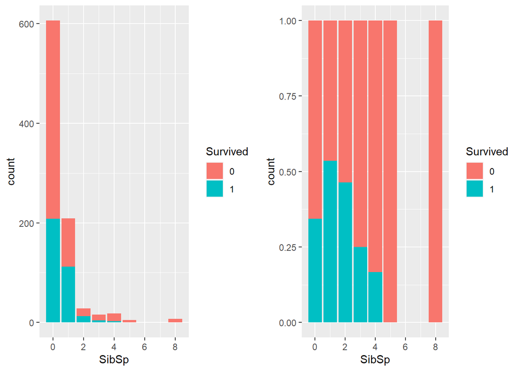

```r
plot1 = ggplot(train, aes(x=SibSp, fill=Survived)) + geom_bar()
plot2 = ggplot(train, aes(x=SibSp, fill=Survived)) + geom_bar(position = "fill")
grid.arrange(plot1, plot2, ncol=2)
```

From the figures we can see there is a higher proportion of survivors among passengers with 1-2 siblings/spouses.

Parch and Survival

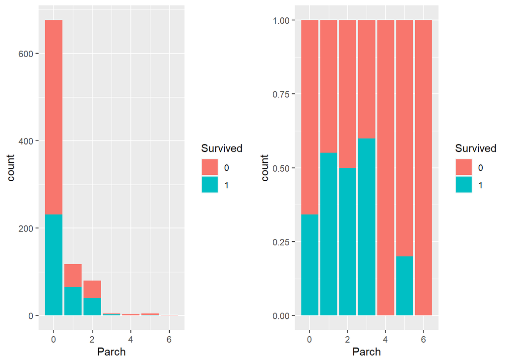

```r
plot1 = ggplot(train, aes(x=Parch, fill=Survived)) + geom_bar()
plot2 = ggplot(train, aes(x=Parch, fill=Survived)) + geom_bar(position = "fill")
grid.arrange(plot1, plot2, ncol=2)
```

These figures show there is a higher proportion of survivors among passengers with 1-3 children/parents.

Fare and Survival

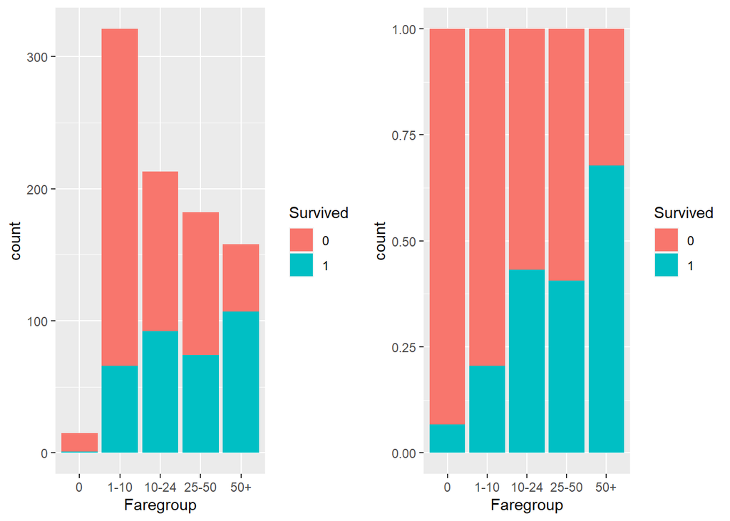

```r
train$Faregroup[train$Fare == 0] <- "0"
train$Faregroup[train$Fare > 0 & train$Fare <= 10] <- "1-10"
train$Faregroup[train$Fare > 10 & train$Fare <= 24] <- "10-24"
train$Faregroup[train$Fare > 24 & train$Fare <= 50] <- "25-50"
train$Faregroup[train$Fare > 50] <- "50+"
plot1 = ggplot(train, aes(x=Faregroup, fill=Survived)) + geom_bar()
plot2 = ggplot(train, aes(x=Faregroup, fill=Survived)) + geom_bar(position = "fill")
grid.arrange(plot1, plot2, ncol=2)
```

These figures show that there was a significantly higher proportion of passengers who survived among those who paid 50 or more for their ticket.

Embarked and Survival

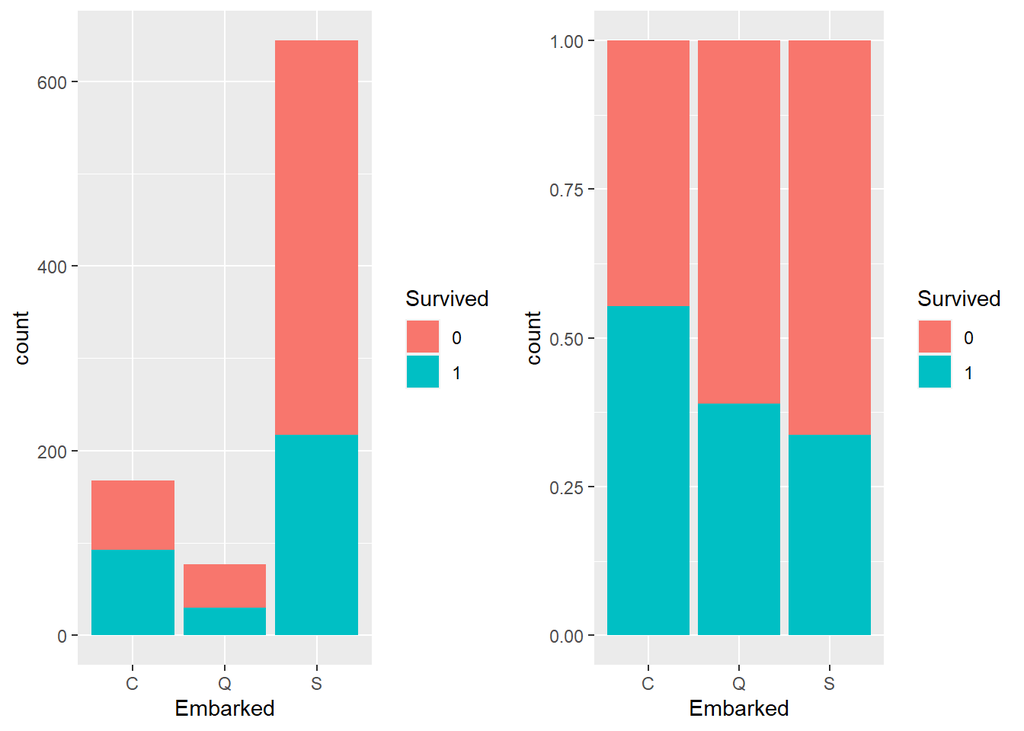

```r
plot1 = ggplot(train, aes(x=Embarked, fill=Survived)) + geom_bar()
plot2 = ggplot(train, aes(x=Embarked, fill=Survived)) + geom_bar(position = "fill")
grid.arrange(plot1, plot2, ncol=2)
```

## 3 Model

### 3.1 Build Model

```r
base = glm(formula = Survived ~ ., data = train, family="binomial"(link=logit))
summary(base)
```

```
##
## Call:
## glm(formula = Survived ~ ., family = binomial(link = logit),
##     data = train)
##
## Deviance Residuals:
##     Min       1Q   Median       3Q      Max
## -2.8748  -0.6397  -0.3960   0.5706   2.8556
##
## Coefficients:
##                  Estimate Std. Error z value Pr(>|z|)
## (Intercept)     2.8133939  1.1791016   2.386 0.017030 *
## Pclass2        -0.6222236  0.3701531  -1.681 0.092765 .
## Pclass3        -1.6634845  0.4517800  -3.682 0.000231 ***
## Sexmale        -2.7806342  0.2106340 -13.201  < 2e-16 ***
## Age            -0.0333445  0.0134293  -2.483 0.013029 *
## SibSp          -0.4123642  0.1271971  -3.242 0.001187 **
## Parch          -0.1739807  0.1316404  -1.322 0.186289
## Fare           -0.0004021  0.0026728  -0.150 0.880425
## EmbarkedQ      -0.0554449  0.3917021  -0.142 0.887437
## EmbarkedS      -0.3780366  0.2444284  -1.547 0.121956
## Agegroup11-20  -1.2166253  0.4694782  -2.591 0.009557 **
## Agegroup21-30  -1.2178419  0.4966450  -2.452 0.014201 *
## Agegroup30+    -0.6748396  0.6500483  -1.038 0.299206
## Agegroup6-10   -1.3699320  0.6303494  -2.173 0.029759 *
## Faregroup1-10   1.6141426  1.1250980   1.435 0.151382
## Faregroup10-24  1.8200340  1.0984715   1.657 0.097544 .
## Faregroup25-50  1.7926623  1.0952799   1.637 0.101690
## Faregroup50+    2.5685171  1.1432203   2.247 0.024657 *
## ---
## Signif. codes:  0 '***' 0.001 '**' 0.01 '*' 0.05 '.' 0.1 ' ' 1
##
## (Dispersion parameter for binomial family taken to be 1)
##
##     Null deviance: 1182.82  on 888  degrees of freedom
## Residual deviance:  767.59  on 871  degrees of freedom
## AIC: 803.59
##
## Number of Fisher Scoring iterations: 5
```

From the logistic regression model, we can see that ‘Pclass’, ‘Sex’, ‘Age’ and ‘SibSp’ are significant predictors of survival probability (at a 0.05 significance level) while ‘Parch’, ‘Fare’ and ‘Embarked’ are not.

```r
anova(base, test='Chisq')
```

```
## Analysis of Deviance Table
##
## Model: binomial, link: logit
##
## Response: Survived
##
## Terms added sequentially (first to last)
##
##
##           Df Deviance Resid. Df Resid. Dev  Pr(>Chi)
## NULL                        888    1182.82
## Pclass     2  101.571       886    1081.25 < 2.2e-16 ***
## Sex        1  254.743       885     826.50 < 2.2e-16 ***
## Age        1   17.130       884     809.37 3.491e-05 ***
## SibSp      1   11.956       883     797.42 0.0005446 ***
## Parch      1    0.435       882     796.98 0.5097075
## Fare       1    1.835       881     795.15 0.1755410
## Embarked   2    4.169       879     790.98 0.1243857
## Agegroup   4   14.326       875     776.65 0.0063251 **
## Faregroup  4    9.066       871     767.59 0.0594603 .
## ---
## Signif. codes:  0 '***' 0.001 '**' 0.01 '*' 0.05 '.' 0.1 ' ' 1
```

Additionally, from the Analysis of Deviance Table it can be seen that adding ‘Pclass’, ‘Sex’, ‘Age’ and ‘SibSp’ result in statistically significant changes in residual deviance (at a 0.05 significance level) indicating that there is strong evidence against the null hypothesis that ‘Pclass’, ‘Sex’, ‘Age’ and ‘SibSp’ are unrelated to survival. Conversely, adding ‘Parch’, ‘Fare’ and ‘Embarked’ result in statistically insignificant changes in residual deviance.

Therefore, we build our final model as:

```r
final = glm(formula = Survived ~ Pclass + Sex + Age + SibSp, data = train, family="binomial"(link=logit))
summary(final)
```

```
##
## Call:
## glm(formula = Survived ~ Pclass + Sex + Age + SibSp, family = binomial(link = logit),
##     data = train)
##
## Deviance Residuals:
##     Min       1Q   Median       3Q      Max
## -2.5520  -0.6443  -0.4165   0.6214   2.4861
##
## Coefficients:
##              Estimate Std. Error z value Pr(>|z|)
## (Intercept)  3.593998   0.357008  10.067  < 2e-16 ***
## Pclass2     -1.086133   0.257805  -4.213 2.52e-05 ***
## Pclass3     -2.201785   0.234923  -9.372  < 2e-16 ***
## Sexmale     -2.741955   0.193677 -14.157  < 2e-16 ***
## Age         -0.029209   0.006499  -4.494 6.99e-06 ***
## SibSp       -0.318597   0.101024  -3.154  0.00161 **
## ---
## Signif. codes:  0 '***' 0.001 '**' 0.01 '*' 0.05 '.' 0.1 ' ' 1
##
## (Dispersion parameter for binomial family taken to be 1)
##
##     Null deviance: 1182.82  on 888  degrees of freedom
## Residual deviance:  797.42  on 883  degrees of freedom
## AIC: 809.42
##
## Number of Fisher Scoring iterations: 5
```

### 3.3 Interpretation

A 95% Wald confidence interval for each coefficient is as follows:

```r
est = c(-1.086133, -2.201785, -2.741955, -0.029209, -0.318597)
se = c(0.257805, 0.234923, 0.193677, 0.006499, 0.101024)

out = c()
for (i in 1:length(est)){
  ci = exp(est[i]+c(-1,1)*qnorm(0.975)*se[i])
  out = rbind(out, ci)
}

rownames(out) = c('Pclass2', 'Pclass3','Sexmale', 'Age', 'SibSp')
colnames(out) = c('Upper', 'Lower')

out
```

```
##              Upper      Lower
## Pclass2 0.20363593 0.55942574
## Pclass3 0.06979272 0.17528459
## Sexmale 0.04408856 0.09419812
## Age     0.95892079 0.98366371
## SibSp   0.59654512 0.88639412
```

### 3.4 Evaluation

```r
pred = predict(final, subset(train, select = c(2, 3, 4, 5)), type = 'response')
for (i in 1:length(pred)){
  if (pred[i] > 0.5){
    pred[i] = 1
  }
  else{
    pred[i] = 0
  }
}
1 - mean(pred != train$Survived)
```

```
## [1] 0.7907762
```

To further evaluate the model, we plot a REceiver-Operator CHaracteristic (ROC) Curve.

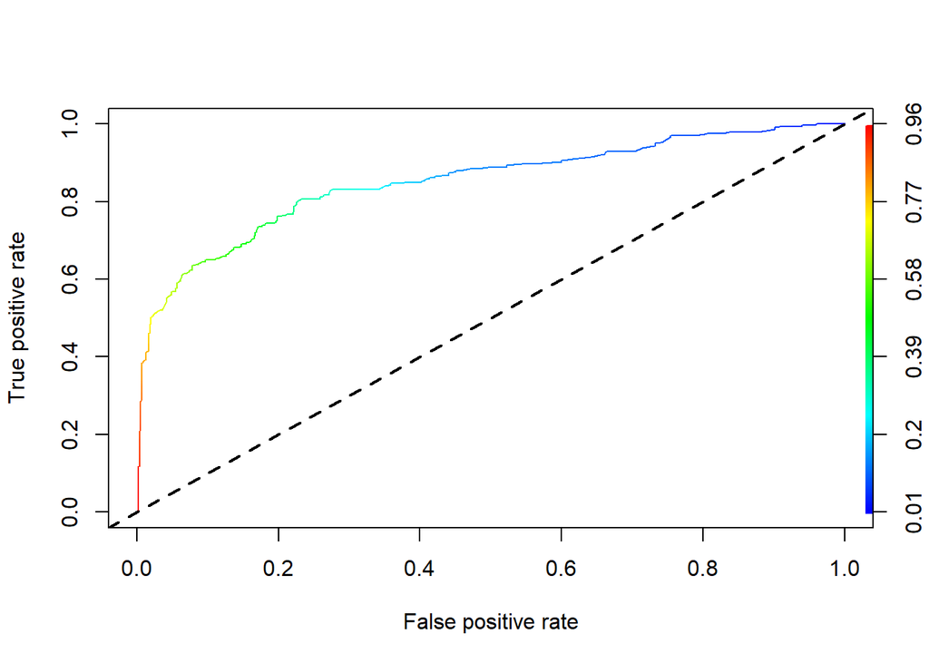

```r
pred = predict(final, subset(train, select = c(2, 3, 4, 5)), type = 'response')
perf = prediction(pred, train$Survived)
roc = performance(perf, 'tpr', 'fpr')
plot(roc,colorize=TRUE)
abline(0,1, lwd = 2, lty = 2)
```

```r
auc = performance(perf, measure = 'auc')
auc@y.values[[1]]
```

```
## [1] 0.8498018
```

We then apply the model to the test dataset and repeat the process outlined above with the training dataset. Consequently, we receive a prediction on the survival status of the passengers in the test dataset.

```r
pred = predict(final, newdata = subset(test, select = c(2, 3, 4, 5)), type = 'response')
for (i in 1:length(pred)){
  if (pred[i] > 0.5){
    pred[i] = 1
  }
  else{
    pred[i] = 0
  }
}
df = data.frame(PassengerId = test$PassengerId, Survived = pred)
write.csv(df,"prediction.csv", row.names = FALSE)
```

Submitting the predictions to Kaggle for evaluation results in an accuracy score of 0.76076, indicating that the model is able to accurately predict whether a passenger will survive or perish for 76% of the passengers in test dataset.